# Task: Correlation

**Student Name:** Sébastien Bagdasarianz  
**Country:** Colombia  
**Semester term:** HS26

```python
from pathlib import Path

_WORKSPACE_ROOT = next(
    (
        parent
        for parent in (Path.cwd(), *Path.cwd().parents)
        if (parent / "gbsv_mc1" / "data").is_dir()
    ),
    None,
)
if _WORKSPACE_ROOT is None:
    raise FileNotFoundError("Could not locate gbsv_mc1/data from the current directory")
DATA_DIR = _WORKSPACE_ROOT / "gbsv_mc1" / "data"
```

## Day 6 – Data & Domain

### Use Case

In Colombian passive acoustic monitoring, autonomous recorders produce long bird-audio streams that conservation teams need to search for target vocalizations. Correlation supports two related but distinct tasks: estimating local periodic structure within a call and locating a known call template in a recording, reducing the need for manual screening across remote habitats.

### Problem Statement

This investigation tests whether autocorrelation can reveal short-lag periodic structure in a Great Kiskadee call and whether normalized cross-correlation can localize a supplied call template in a 10-second Colombian field recording. Strong background variation, non-stationary calls, or a template that differs in duration, amplitude envelope, or timing can obscure peaks and cause false localization; results must therefore be checked against the known sample position and interpreted as a single-recording demonstration.

### Experimental Objective

The objective is to characterize short-term repeating structure within a representative bird call and evaluate how reliably its acoustic template can be found in the surrounding recording. The analysis distinguishes periodicity measurement from event localization and tests whether the latter remains stable under shorter templates, additive noise, and amplitude changes.

### Data Definition, Source, and Visualization

The signal is a 10 s, mono, 48 kHz excerpt of normalized sound-pressure amplitude from the PteroSet v5 Great Kiskadee recording `P5-G022_04-13_tlapse.wav`, Pijavay, Magdalena, Colombia. The companion 2 s template is the exact excerpt beginning at 0.80 s in this stream, so its known localization is 0.80 s rather than an independent later call. The signal is suitable for demonstrating local autocorrelation and cross-correlation localization, but exact reuse of the template makes the baseline a controlled software check rather than an independent biological detection trial. The dataset is curated with species annotations and recording metadata; both audio files are provided in this project’s `data/` folder.

*Guideline: Visualize a representative excerpt of your signal. If the data are audio-based, additionally provide a playable audio segment. All visualizations must include clearly labeled axes and the correct units.*

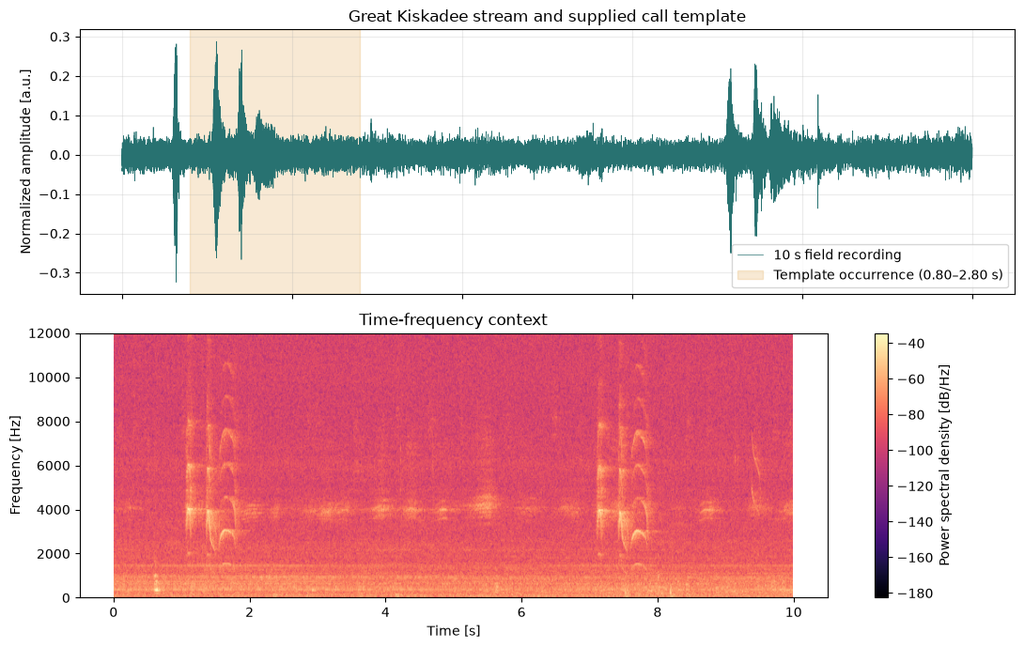

```
Stream: 10.0 s at 48,000 Hz
Template: 2.0 s at 48,000 Hz
Playable stream excerpt:
```

[interactive chart not shown]

```python
from pathlib import Path

import matplotlib.pyplot as plt
import numpy as np
import soundfile as sf
import IPython.display as ipd


data_dir = DATA_DIR
stream, sample_rate = sf.read(data_dir / "segment_10s_48khz.wav")
template, template_rate = sf.read(data_dir / "call_template_2s_48khz.wav")
if stream.ndim == 2:
    stream = stream.mean(axis=1)
if template.ndim == 2:
    template = template.mean(axis=1)
if sample_rate != template_rate:
    raise ValueError("Stream and template sample rates must match")
time = np.arange(len(stream)) / sample_rate

fig, axes = plt.subplots(2, 1, figsize=(11, 7), sharex=True)
axes[0].plot(time, stream, color="#287271", linewidth=0.5, label="10 s field recording")
axes[0].axvspan(0.80, 2.80, color="#e09f3e", alpha=0.22, label="Template occurrence (0.80–2.80 s)")
axes[0].set_ylabel("Normalized amplitude [a.u.]")
axes[0].set_title("Great Kiskadee stream and supplied call template")
axes[0].grid(alpha=0.25)
axes[0].legend()

_, _, _, image = axes[1].specgram(stream, NFFT=1024, Fs=sample_rate, noverlap=768, cmap="magma")
axes[1].set_ylim(0, 12000)
axes[1].set_xlabel("Time [s]")
axes[1].set_ylabel("Frequency [Hz]")
axes[1].set_title("Time-frequency context")
fig.colorbar(image, ax=axes[1], label="Power spectral density [dB/Hz]")
plt.tight_layout()
plt.show()

print(f"Stream: {len(stream) / sample_rate:.1f} s at {sample_rate:,} Hz")
print(f"Template: {len(template) / template_rate:.1f} s at {template_rate:,} Hz")
print("Playable stream excerpt:")
ipd.display(ipd.Audio(stream, rate=sample_rate))
```

### Observations

The 10 s waveform contains the supplied 2 s template verbatim beginning at 0.80 s, as confirmed by the exact normalized match in the correlation analysis. The recording has a 48 kHz sample rate and a 24 kHz Nyquist frequency. This known embedded location provides a ground-truth check for localization, but it is not evidence that an independent later call can be detected.

### Task-Specific Answers: Correlation

Autocorrelation compares a window with delayed copies of itself; a nonzero local peak at lag $\tau$ indicates repeated structure and maps to period $T=\tau/f_s$. Cross-correlation compares the stream with a separate template; a peak at start index $n$ maps to event time $t=n/f_s$. Here, the autocorrelation search is limited to $0.30$–$0.80$ ms (1.25–3.33 kHz), while cross-correlation uses the supplied call template and normalizes by the local stream energy to reduce sensitivity to amplitude variation. These methods answer different questions: local periodicity versus template localization.

## Day 7 – Methodological Design

*Guidelines: Establish the theoretical and methodological foundation for your selected signal or image processing operation in direct alignment with the country-specific use case defined previously. Formally state the relevant theoretical principle and explain its assumptions, validity conditions, and domain-specific applicability. Select and justify concrete methods and parameter values appropriate for your one-dimensional signal or two-dimensional image data, explaining why these choices fit the defined analytical objective. Derive necessary quantities mathematically where applicable, documenting each step with explicit assumptions and consistent units (temporal, spatial, or frequency units as relevant). Specify and justify the experimental design to be executed on the next day: define the parameters to vary, the control/baseline configuration, and the structured parameter sweep (ranges and step sizes). Theoretically predict the expected qualitative effects of these variations on the signal or image and identify likely failure modes (e.g., aliasing, instability, sensitivity to noise, loss of detail). Discuss methodological limitations, idealizations, and potential sources of misinterpretation. No simulations, visualizations, or experimental demonstrations should be included.*

### Theoretical Foundation and Method Choice

For a finite call window $x[n]$, autocorrelation $R_{xx}[k]=\sum_n x[n]x[n+k]$ measures repeated waveform structure over lag $k$. Cross-correlation $R_{xy}[k]=\sum_n x[n]y[n+k]$ slides template $y[n]$ across stream $x[n]$ to measure match strength. The normalized cross-correlation divides by template energy and local window energy, making its score comparable across candidate positions and less sensitive to recorder gain.

### Parameter Definition and Mathematical Specification

The stream and template are mono signals at $f_s=48{,}000$ Hz, with $\Delta t=1/f_s=20.83\,\mu$s. For local periodicity, examine lags 14–38 samples, corresponding to 0.292–0.792 ms or approximately 3.43–1.26 kHz; for template localization, the full 2 s template contains 96,000 samples. Sample lag $k$ maps to physical time $k/f_s$ seconds, while normalized correlation is dimensionless.

### Experimental Design for Next Days

The baseline is the provided 10 s stream, the full 2 s template, normalized valid cross-correlation, and a local autocorrelation lag interval of 0.30–0.80 ms. Day 8 implements both analyses and compares the detected template start with the known 0.80 s position. Day 9 varies template duration (0.25, 0.5, 1, 1.5, and 2 s) and evaluates additive noise at 30, 20, 10, and 0 dB SNR plus a 0.5 amplitude change; all other settings remain fixed.

### Methodological Limitations and Risk Factors

Autocorrelation peaks can reflect harmonics or multiple periodic scales rather than a unique fundamental pitch, especially in a short, non-stationary vocalization. The provided template is extracted from the same recording, so the exact match is an optimistic localization baseline; noise is synthetic and does not model competing birds, reverberation, or real recorder changes. Energy normalization also becomes unstable for near-silent windows, which is controlled here with a small denominator floor.

## Day 8 – Technical Implementation

The following cell implements the Day 7 autocorrelation and template-localization plan on the supplied audio files. It reports the candidate short-lag periodicity and compares normalized cross-correlation localization with the known template position.

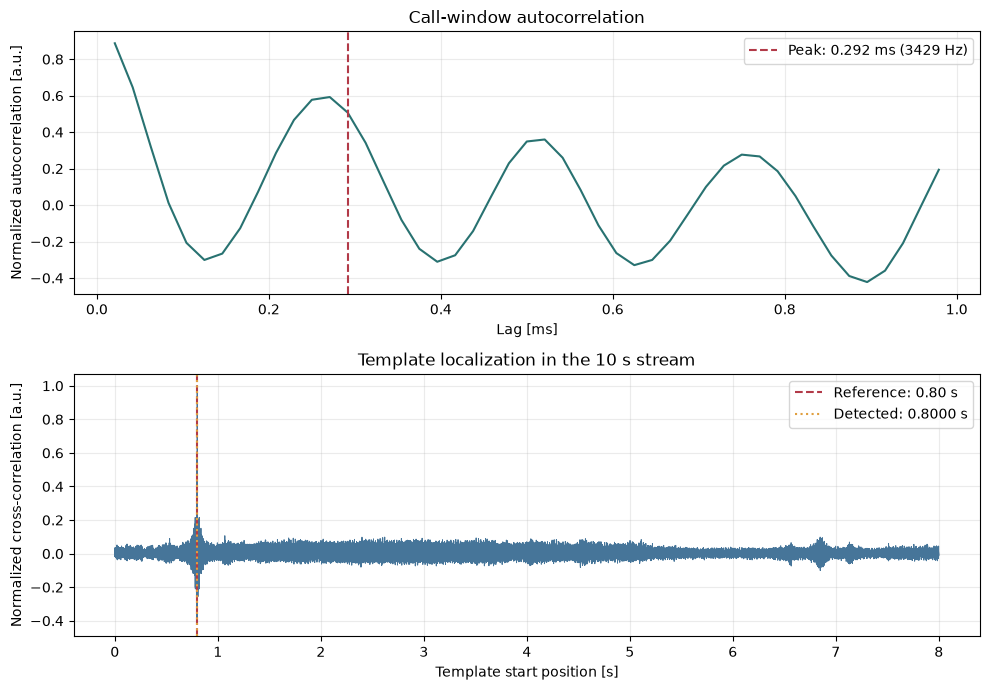

```
Autocorrelation peak: 14 samples = 0.2917 ms; candidate frequency = 3428.57 Hz
Template start: detected 0.800000 s; reference 0.80 s; absolute error 0.000000 s
Normalized cross-correlation peak: 1.000000
```

```python
from pathlib import Path

import matplotlib.pyplot as plt
import numpy as np
import soundfile as sf
from scipy import signal


data_dir = DATA_DIR
stream, sample_rate = sf.read(data_dir / "segment_10s_48khz.wav")
template, template_rate = sf.read(data_dir / "call_template_2s_48khz.wav")
if stream.ndim == 2:
    stream = stream.mean(axis=1)
if template.ndim == 2:
    template = template.mean(axis=1)
if sample_rate != template_rate:
    raise ValueError("Stream and template sample rates must match")

reference_start = 0.80
call_start = round(reference_start * sample_rate)
call_window = stream[call_start:call_start + len(template)]
centered_call = call_window - np.mean(call_window)
auto = signal.correlate(centered_call, centered_call, mode="full", method="fft")[len(centered_call) - 1:]
auto /= auto[0]
lags = np.arange(len(auto))
lag_min = round(0.30e-3 * sample_rate)
lag_max = round(0.80e-3 * sample_rate)
period_samples = lag_min + int(np.argmax(auto[lag_min:lag_max + 1]))
period_ms = 1000 * period_samples / sample_rate
pitch_hz = sample_rate / period_samples

numerator = signal.correlate(stream, template, mode="valid", method="fft")
prefix_energy = np.concatenate(([0.0], np.cumsum(stream**2)))
local_energy = prefix_energy[len(template):] - prefix_energy[:-len(template)]
scores = numerator / (np.sqrt(local_energy) * np.linalg.norm(template) + 1e-12)
detected_sample = int(np.argmax(scores))
detected_time = detected_sample / sample_rate
localization_error = abs(detected_time - reference_start)

fig, axes = plt.subplots(2, 1, figsize=(10, 7))
lag_times_ms = 1000 * lags / sample_rate
axes[0].plot(lag_times_ms[1:round(1e-3 * sample_rate)], auto[1:round(1e-3 * sample_rate)], color="#287271")
axes[0].axvline(period_ms, color="#b23a48", linestyle="--", label=f"Peak: {period_ms:.3f} ms ({pitch_hz:.0f} Hz)")
axes[0].set_xlabel("Lag [ms]")
axes[0].set_ylabel("Normalized autocorrelation [a.u.]")
axes[0].set_title("Call-window autocorrelation")
axes[0].grid(alpha=0.25)
axes[0].legend()

score_times = np.arange(len(scores)) / sample_rate
axes[1].plot(score_times, scores, color="#467599", linewidth=0.7)
axes[1].axvline(reference_start, color="#b23a48", linestyle="--", label=f"Reference: {reference_start:.2f} s")
axes[1].axvline(detected_time, color="#e09f3e", linestyle=":", label=f"Detected: {detected_time:.4f} s")
axes[1].set_xlabel("Template start position [s]")
axes[1].set_ylabel("Normalized cross-correlation [a.u.]")
axes[1].set_title("Template localization in the 10 s stream")
axes[1].grid(alpha=0.25)
axes[1].legend()
plt.tight_layout()
plt.show()

print(f"Autocorrelation peak: {period_samples} samples = {period_ms:.4f} ms; candidate frequency = {pitch_hz:.2f} Hz")
print(f"Template start: detected {detected_time:.6f} s; reference {reference_start:.2f} s; absolute error {localization_error:.6f} s")
print(f"Normalized cross-correlation peak: {scores[detected_sample]:.6f}")
```

## Day 9 – Evaluation

The cross-correlation localization error is measured as the absolute difference between detected and known start times in seconds. Autocorrelation reports the strongest nonzero peak within the planned lag interval as a candidate period in milliseconds and corresponding frequency in hertz; because no independent pitch annotation is provided, this is a descriptive estimate rather than a ground-truth accuracy score.

Compare five template durations (0.25–2.00 s) using identical localization metrics, then retain the 2 s baseline while perturbing the stream with seeded white noise at 30, 20, 10, and 0 dB SNR and halving the embedded template occurrence amplitude. The same known 0.80 s reference and normalized score are used throughout; the autocorrelation peak is also reported for 0.20–0.40, 0.30–0.80, and 0.50–1.00 ms lag windows.

```
Autocorrelation lag-window comparison
range [ms] | peak lag [ms] | candidate frequency [Hz] | normalized peak
0.20-0.40 | 0.27083 | 3692.31 | 0.5925
0.30-0.80 | 0.29167 | 3428.57 | 0.5073
0.50-1.00 | 0.52083 | 1920.00 | 0.3597

Template-duration comparison
duration [s] | detected start [s] | absolute error [s] | normalized peak
0.25 | 0.8000 | 0.0000 | 1.0000
0.50 | 0.8000 | 0.0000 | 1.0000
1.00 | 0.8000 | 0.0000 | 1.0000
1.50 | 0.8000 | 0.0000 | 1.0000
2.00 | 0.8000 | 0.0000 | 1.0000

Cross-correlation robustness
condition | detected start [s] | absolute error [s] | normalized peak
white noise 30 dB | 0.8000 | 0.0000 | 0.9997
white noise 20 dB | 0.8000 | 0.0000 | 0.9967
white noise 10 dB | 0.8000 | 0.0000 | 0.9685
white noise 0 dB | 0.8000 | 0.0000 | 0.7739
embedded amplitude x0.5 | 0.8000 | 0.0000 | 1.0000
```

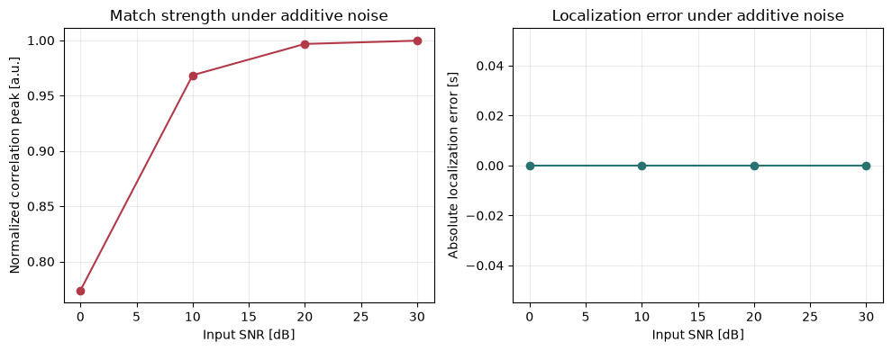

```python
from pathlib import Path

import matplotlib.pyplot as plt
import numpy as np
import soundfile as sf
from scipy import signal


data_dir = DATA_DIR
stream, sample_rate = sf.read(data_dir / "segment_10s_48khz.wav")
template, _ = sf.read(data_dir / "call_template_2s_48khz.wav")
if stream.ndim == 2:
    stream = stream.mean(axis=1)
if template.ndim == 2:
    template = template.mean(axis=1)
reference_start = 0.80


def locate_template(search_signal, search_template):
    numerator = signal.correlate(search_signal, search_template, mode="valid", method="fft")
    cumulative_energy = np.concatenate(([0.0], np.cumsum(search_signal**2)))
    local_energy = cumulative_energy[len(search_template):] - cumulative_energy[:-len(search_template)]
    scores = numerator / (np.sqrt(local_energy) * np.linalg.norm(search_template) + 1e-12)
    peak_index = int(np.argmax(scores))
    return peak_index / sample_rate, float(scores[peak_index])


call_window = stream[round(reference_start * sample_rate):round(reference_start * sample_rate) + len(template)]
centered_call = call_window - np.mean(call_window)
auto = signal.correlate(centered_call, centered_call, mode="full", method="fft")[len(centered_call) - 1:]
auto /= auto[0]
lag_ranges_ms = [(0.20, 0.40), (0.30, 0.80), (0.50, 1.00)]
print("Autocorrelation lag-window comparison")
print("range [ms] | peak lag [ms] | candidate frequency [Hz] | normalized peak")
for lower_ms, upper_ms in lag_ranges_ms:
    lower = round(lower_ms * 1e-3 * sample_rate)
    upper = round(upper_ms * 1e-3 * sample_rate)
    peak_lag = lower + int(np.argmax(auto[lower:upper + 1]))
    print(f"{lower_ms:.2f}-{upper_ms:.2f} | {1000 * peak_lag / sample_rate:.5f} | {sample_rate / peak_lag:.2f} | {auto[peak_lag]:.4f}")

print("\nTemplate-duration comparison")
print("duration [s] | detected start [s] | absolute error [s] | normalized peak")
for duration in [0.25, 0.50, 1.00, 1.50, 2.00]:
    partial_template = template[:round(duration * sample_rate)]
    detected_time, peak_score = locate_template(stream, partial_template)
    print(f"{duration:.2f} | {detected_time:.4f} | {abs(detected_time - reference_start):.4f} | {peak_score:.4f}")

rng = np.random.default_rng(2026)
stream_rms = np.sqrt(np.mean(stream**2))
noise_results = []
for snr_db in [30, 20, 10, 0]:
    noise_rms = stream_rms / (10 ** (snr_db / 20))
    noisy_stream = stream + rng.normal(0, noise_rms, len(stream))
    detected_time, peak_score = locate_template(noisy_stream, template)
    noise_results.append((snr_db, detected_time, abs(detected_time - reference_start), peak_score))

scaled_stream = stream.copy()
match_start = round(reference_start * sample_rate)
scaled_stream[match_start:match_start + len(template)] *= 0.5
scaled_time, scaled_score = locate_template(scaled_stream, template)

print("\nCross-correlation robustness")
print("condition | detected start [s] | absolute error [s] | normalized peak")
for snr_db, detected_time, timing_error, peak_score in noise_results:
    print(f"white noise {snr_db} dB | {detected_time:.4f} | {timing_error:.4f} | {peak_score:.4f}")
print(f"embedded amplitude x0.5 | {scaled_time:.4f} | {abs(scaled_time - reference_start):.4f} | {scaled_score:.4f}")

fig, axes = plt.subplots(1, 2, figsize=(10, 4))
axes[0].plot([row[0] for row in noise_results], [row[3] for row in noise_results], marker="o", color="#b23a48")
axes[0].set_xlabel("Input SNR [dB]")
axes[0].set_ylabel("Normalized correlation peak [a.u.]")
axes[0].set_title("Match strength under additive noise")
axes[0].grid(alpha=0.25)
axes[1].plot([row[0] for row in noise_results], [row[2] for row in noise_results], marker="o", color="#287271")
axes[1].set_xlabel("Input SNR [dB]")
axes[1].set_ylabel("Absolute localization error [s]")
axes[1].set_title("Localization error under additive noise")
axes[1].grid(alpha=0.25)
plt.tight_layout()
plt.show()
```

## Day 10 – Analytical & Communication

*Focus: connect measured periodicity, localization error, and robustness results to the Colombian acoustic-monitoring use case.*

### Observations

The full 2 s template localized at 0.8000 s with zero absolute timing error and a normalized peak of 1.0000. Template durations from 0.25 to 2 s all returned 0.8000 s in this exact-template recording. Under 30, 20, 10, and 0 dB additive noise, the detected time remained 0.8000 s while the score decreased from 0.9997 to 0.7739.

### Interpretation

The unchanged detection time indicates that the normalized matcher locates this embedded pattern reliably under the tested perturbations. The falling score at lower SNR shows that match confidence degrades even when the location remains correct. The estimated autocorrelation lag varies with its search interval, demonstrating that a peak is not a pitch truth unless the target scale is specified and independently validated.

### Discussion and Critical Reflection

For this supplied excerpt, the baseline cross-correlation correctly identifies the template’s known start at 0.80 s, and remains correctly localized down to the tested 0 dB SNR. Shorter templates also match perfectly because they are literal prefixes of the same embedded source, so that duration result should not be generalized to independent calls. The 0.5 amplitude perturbation is handled by energy normalization, while additive noise reduces the similarity score. Autocorrelation estimates 3,428.6 Hz in the planned window, but the peak changes when the lag range changes and has no annotation-based ground truth. Field use would require independent recordings, a calibrated decision threshold, and tests with competing calls and non-white environmental noise.